# Reproducible Research: Peer Assessment 1

## Load packages

```r
library(ggplot2)
library(dplyr)
```

## Loading and preprocessing the data

```r
activity <- read.csv("activity.csv", stringsAsFactors=FALSE)
str(activity)
```

```
## 'data.frame':    17568 obs. of  3 variables:
##  $ steps   : int  NA NA NA NA NA NA NA NA NA NA ...
##  $ date    : chr  "2012-10-01" "2012-10-01" "2012-10-01" "2012-10-01" ...
##  $ interval: int  0 5 10 15 20 25 30 35 40 45 ...
```

### Summarizing steps per day

```r
activity_steps_day <- na.omit(activity) %>%
  group_by(date) %>%
  summarise(steps_day=sum(steps))

head(activity_steps_day)
```

```
## # A tibble: 6 × 2
##         date steps_day
##        <chr>     <int>
## 1 2012-10-02       126
## 2 2012-10-03     11352
## 3 2012-10-04     12116
## 4 2012-10-05     13294
## 5 2012-10-06     15420
## 6 2012-10-07     11015
```

```r
tail(activity_steps_day)
```

```
## # A tibble: 6 × 2
##         date steps_day
##        <chr>     <int>
## 1 2012-11-24     14478
## 2 2012-11-25     11834
## 3 2012-11-26     11162
## 4 2012-11-27     13646
## 5 2012-11-28     10183
## 6 2012-11-29      7047
```

### Summarizing steps on average through the 24 hours

```r
activity_steps_hour <- na.omit(activity) %>%
  group_by(interval) %>%
  summarise(steps_interval=mean(steps))

activity_steps_hour <- activity_steps_hour %>% mutate(hour = trunc(interval/100))
```

## What is the mean total number of steps taken per day?

For this part of the assignment the missing values in the dataset are ignore.

### Histogram of the total number of steps taken each day

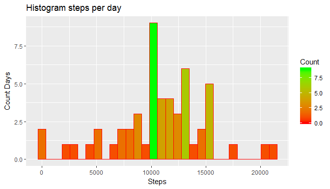

```r
ggplot(data=activity_steps_day, aes(activity_steps_day$steps_day)) +
  geom_histogram(col="red",
                 aes(fill=..count..)) +
  scale_fill_gradient("Count", low = "red", high = "green") +
  labs(title="Histogram steps per day") +
  labs(x="Steps", y="Count Days")
```

### Mean and median of total number of steps taken per day

```r
activity_steps_day %>%
  summarise(steps_median=median(steps_day))
```

```
## # A tibble: 1 × 1
##   steps_median
##          <int>
## 1        10765
```

```r
activity_steps_day %>%
  summarise(steps_mean=mean(steps_day))
```

```
## # A tibble: 1 × 1
##   steps_mean
##        <dbl>
## 1   10766.19
```

## Average daily activity pattern

### Time series plot 5 minute interval

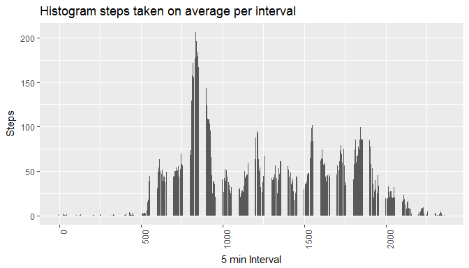

```r
ggplot(data=activity_steps_hour, aes(x=interval, y=steps_interval)) +
  geom_bar(stat="identity") +
  labs(title="Histogram steps taken on average per interval") +
  labs(x="5 min Interval", y="Steps") +
  theme(axis.text.x = element_text(angle = 90, hjust = 1))
```

**From the histogram we can observe that the most active hour is 8AM.

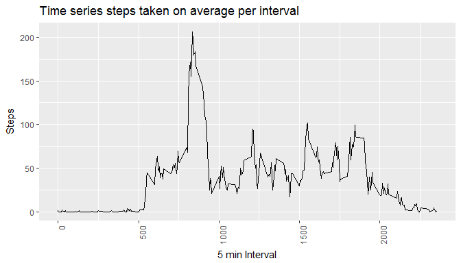

```r
ggplot(data=activity_steps_hour, aes(x=interval, y=steps_interval)) + geom_line() +
  labs(title="Time series steps taken on average per interval") +
  labs(x="5 min Interval", y="Steps") +
  theme(axis.text.x = element_text(angle = 90, hjust = 1))
```

### 5-minute interval which contains on average maximum number of steps across all the days in the dataset

```r
activity_steps_hour %>%
  summarise(steps_max=max(steps_interval))
```

```
## # A tibble: 1 × 1
##   steps_max
##       <dbl>
## 1  206.1698
```

### The 5-minute interval with more steps on average is at 8:35am. I could find the max average but I was not able to display in the same result which time specific interval was it. I look for it manually in the data.

## Imputing missing values

### Total number of missing values in the dataset

```r
sum(is.na(activity$steps))
```

```
## [1] 2304
```

Total number of rows with missing values in the data set is 2304.

```r
activity_steps_hour %>%
  summarise(steps_mean=mean(steps_interval))
```

```
## # A tibble: 1 × 1
##   steps_mean
##        <dbl>
## 1    37.3826
```

```r
activity2 <- activity
activity2$steps[is.na(activity2$steps)] <- 37

sum(is.na(activity2$steps))
```

```
## [1] 0
```

### Histogram of the total number of steps taken each day (Missing values filled)

```r
activity_steps_day <- activity2 %>%
  group_by(date) %>%
  summarise(steps_day=sum(steps))
```

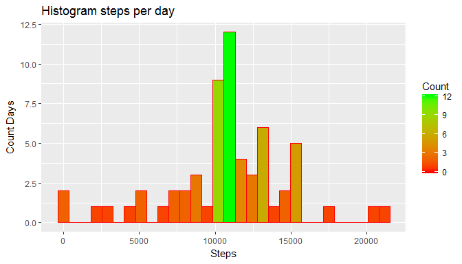

```r
ggplot(data=activity_steps_day, aes(activity_steps_day$steps_day)) +
  geom_histogram(col="red",
                 aes(fill=..count..)) +
  scale_fill_gradient("Count", low = "red", high = "green") +
  labs(title="Histogram steps per day") +
  labs(x="Steps", y="Count Days")
```

### Mean and median of total number of steps taken per day (Missing values filled)

```r
activity_steps_day %>%
  summarise(steps_median=median(steps_day))
```

```
## # A tibble: 1 × 1
##   steps_median
##          <dbl>
## 1        10656
```

```r
activity_steps_day %>%
  summarise(steps_mean=mean(steps_day))
```

```
## # A tibble: 1 × 1
##   steps_mean
##        <dbl>
## 1   10751.74
```

## Pattern differences in activity between weekdays and weekends

### define day of the week in the dataset and recreate the average 5-minute interval dataset

```r
activity2$day <- weekdays(as.Date(activity$date))

activity2$wday <- "weekday"
activity2$wday[activity2$day=="Saturday"] <- "weekend"
activity2$wday[activity2$day=="Sunday"] <- "weekend"


activity_steps_hour <- activity2 %>%
  group_by(interval, wday) %>%
  summarise(steps_interval=mean(steps))
```

### panel plot containing a time series plot of the 5-minute interval (x-axis) and the average number of steps taken, averaged across all weekday days or weekend days (y-axis).

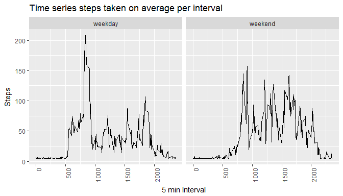

```r
ggplot(data=activity_steps_hour, aes(x=interval, y=steps_interval)) + geom_line() +
  labs(title="Time series steps taken on average per interval") +
  labs(x="5 min Interval", y="Steps") +
  theme(axis.text.x = element_text(angle = 90, hjust = 1)) +
  facet_wrap(~ wday)
```